# Extensive transcriptional and chromatin changes underlie astrocyte maturation in vivo and in culture

**Michael Lattke<sup>1</sup>, Robert Goldstone<sup>2</sup>, James Ellis<sup>3</sup>, Stefan Boeing<sup>4</sup>, Jeronimo Jurado-Arjona<sup>5</sup>, Nicolás Marichal<sup>5</sup>, James MacRae<sup>3</sup>, Benedikt Berninger<sup>5,6</sup>, Francois Guillemot<sup>1</sup>***

<sup>1</sup>Neural Stem Cell Biology Laboratory, The Francis Crick Institute, London, NW1 1AT, UK <sup>2</sup>Advanced Sequencing Facility, The Francis Crick Institute, London, NW1 1AT, UK <sup>3</sup>Metabolomics Facility, The Francis Crick Institute, London, NW1 1AT, UK <sup>4</sup>Bionformatics & Biostatistics, The Francis Crick Institute, London, NW1 1AT, UK <sup>5</sup>Institute of Psychiatry, Psychology & Neuroscience, Centre for Developmental Neurobiology, King's College London, London, SE1 1UL, UK <sup>6</sup>MRC Centre for Neurodevelopmental Disorders, King's College London, London, SE1 1UL, UK

*lead author

Corresponding author e-mail address: Francois.Guillemot@crick.ac.uk

### Online Resource

**Version** Figures_v3_03_for_resource_v010_21-03-16

# Summary

# Single-cell RNA-Seq analysis of striatal astrocyte maturation (related to Figure 1)

**Rationale** Astrocytes have essential functions during brain development and homeostasis. Immature astrocytes in the developing brain support developmental processes such as neuronal maturation, while mature astrocytes in the adult brain support brain homeostasis and modulate neuronal signalling. However, the stages of astrocyte development and the molecular mechanisms underlying these functional changes are not well understood. Therefore, to further elcuidate the stages and molecular changes, we have analysed the gene expression changes during astrocyte maturation in the murine striatum, which occurs between birth and around 4 weeks of age, using scRNA-Seq.

**Experimental design** Astrocytes were acutely purified from striatum tissue at postnatal day 3 (P3, for immature astrocytes) or at 3 months of age (3m, for mature astrocytes) using ACSA2-MACS. Astrocytes from 3 independent preparations (each 2-5 animals) were analysed using 10X-Genomics scRNA-Seq.

**Analysis outline** Cells with >500 features (detected genes) and < 10% mitochondrial content were clustered using Seurat3 (Figure 1C). Sox9-postive astroglial lineage clusters were isolated and reclustered (Figure 1D). Pseudotime analysis was performed using Slingshot (Figure 1E). Changes in gene expression along pseudotime were identified using tradeSeq, and the identified genes grouped according to their mean expression in pseudotime bins (Figure 1F).

**Results summary** In the Seurat analysis we identified several clusters of transcriptionally clearly distinct immature and mature astrocytes. Slingshot pseudotime analysis identified a likely maturation trajectory which includes two populations of proliferating progenitors, two consecutive stages of postmitotic immature astrocytes, and two main populations of mature adult astrocytes. Our pseudotemporal gene expression analysis revealed 4 groups of immature astrocyte genes and two groups of mature astrocyte genes with distinct expression patterns.

## UMAP clustering, complete dataset (Figure 1C)

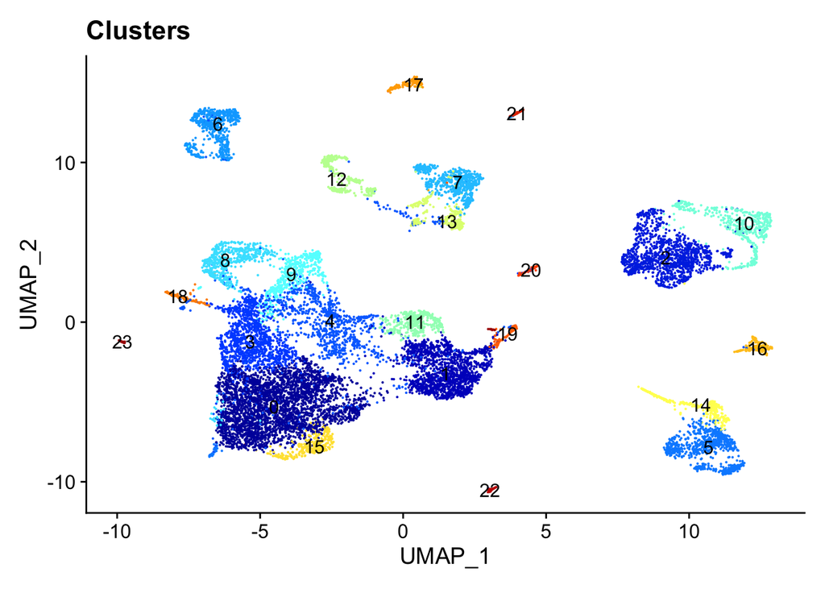

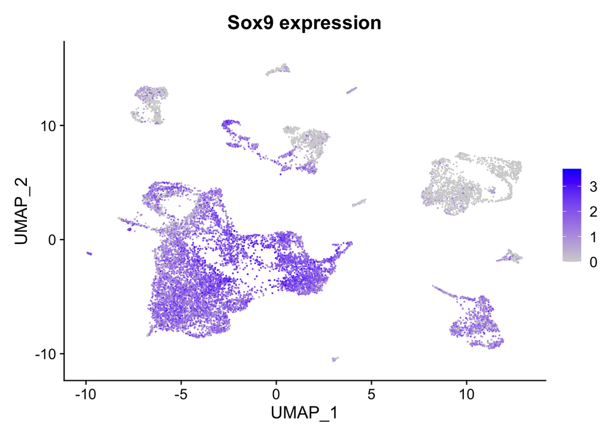

## Astroglial lineage (Sox9+ cells) reclustered (UMAP, Figure 1D)